# Chapter 8

## Answers

### AJ Smit

### 2020/07/01 (updated: 2020-07-02)

## Fit linear model to raw data

```r
lungs <- read_tsv("../data/LungCapData.csv")
mod <- lm(LungCap ~ Age, data = lungs)
summary(mod)
```

```
R>
R> Call:
R> lm(formula = LungCap ~ Age, data = lungs)
R>
R> Residuals:
R>     Min      1Q  Median      3Q     Max
R> -4.7799 -1.0203 -0.0005  0.9789  4.2650
R>
R> Coefficients:
R>             Estimate Std. Error t value Pr(>|t|)
R> (Intercept)  1.14686    0.18353   6.249 7.06e-10 ***
R> Age          0.54485    0.01416  38.476  < 2e-16 ***
R> ---
R> Signif. codes:  0 '***' 0.001 '**' 0.01 '*' 0.05 '.' 0.1 ' ' 1
R>
R> Residual standard error: 1.526 on 723 degrees of freedom
R> Multiple R-squared:  0.6719,	Adjusted R-squared:  0.6714
R> F-statistic:  1480 on 1 and 723 DF,  p-value: < 2.2e-16
```

## Fit linear model to residuals

```r
lungs$resid <- mod$residuals # create variable to contain residuals of of mod
lungs$fitted <- mod$fitted.values # create variable for fitted.values of mod
mod_resid <- lm(resid ~ Age, data = lungs) # fit model to residuals
lungs$resid_resid <- mod_resid$residuals # add residuals of mod_resid
lungs$resid_fitted <- mod_resid$fitted.values # add fitted.values of mod_resid
summary(mod_resid)
```

```
R>
R> Call:
R> lm(formula = resid ~ Age, data = lungs)
R>
R> Residuals:
R>     Min      1Q  Median      3Q     Max
R> -4.7799 -1.0203 -0.0005  0.9789  4.2650
R>
R> Coefficients:
R>               Estimate Std. Error t value Pr(>|t|)
R> (Intercept)  3.949e-16  1.835e-01       0        1
R> Age         -2.267e-17  1.416e-02       0        1
R>
R> Residual standard error: 1.526 on 723 degrees of freedom
R> Multiple R-squared:  1.589e-32,	Adjusted R-squared:  -0.001383
R> F-statistic: 1.149e-29 on 1 and 723 DF,  p-value: 1
```

## Plot the two models

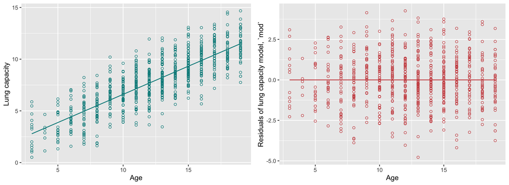

```r
mod_plt <- ggplot(data = lungs, aes(x = Age, y = LungCap)) +
  geom_point(shape = 1, colour = "cyan4") +
  geom_line(aes(y = fitted), colour = "cyan4", size = 0.6) +
  labs(x = "Age", y = "Lung capacity")
mod_resid_plt <- ggplot(data = lungs, aes(x = Age, y = resid_resid)) +
  geom_point(shape = 1, colour = "indianred3") +
  geom_line(aes(y = resid_fitted), colour = "indianred3", size = 0.6) +
  labs(x = "Age", y = "Residuals of lung capacity model, `mod`")
ggpubr::ggarrange(mod_plt, mod_resid_plt, ncol = 2)
```

## What is the relationship between the residuals and the raw data?

```r
lungs_sub <- lungs %>%
  group_by(Age) %>%
  sample_n(1) %>%
  ungroup()
mod_vec <- ggplot(data = lungs, aes(x = Age)) +
  geom_point(aes(y = LungCap), shape = 1, colour = "grey80") +
  geom_line(aes(y = fitted), colour = "cyan4", size = 0.6) +
  geom_point(aes(y = resid_resid), shape = 5, colour = "grey80") +
  geom_line(aes(y = resid_fitted), colour = "indianred3", size = 0.6) +
  geom_point(data = lungs_sub, aes(y = LungCap), shape = 1, colour = "cyan4", size = 3) +
  geom_point(data = lungs_sub, aes(y = resid_resid), shape = 5, colour = "indianred3", size = 3) +
  geom_segment(data = lungs_sub,
               aes(x = lungs_sub$Age, xend = lungs_sub$Age,
                   y = lungs_sub$LungCap, yend = lungs_sub$resid),
               alpha = 0.4, arrow = arrow(), size = 1.0) +
  labs(x = "Age", y = "Y")
```

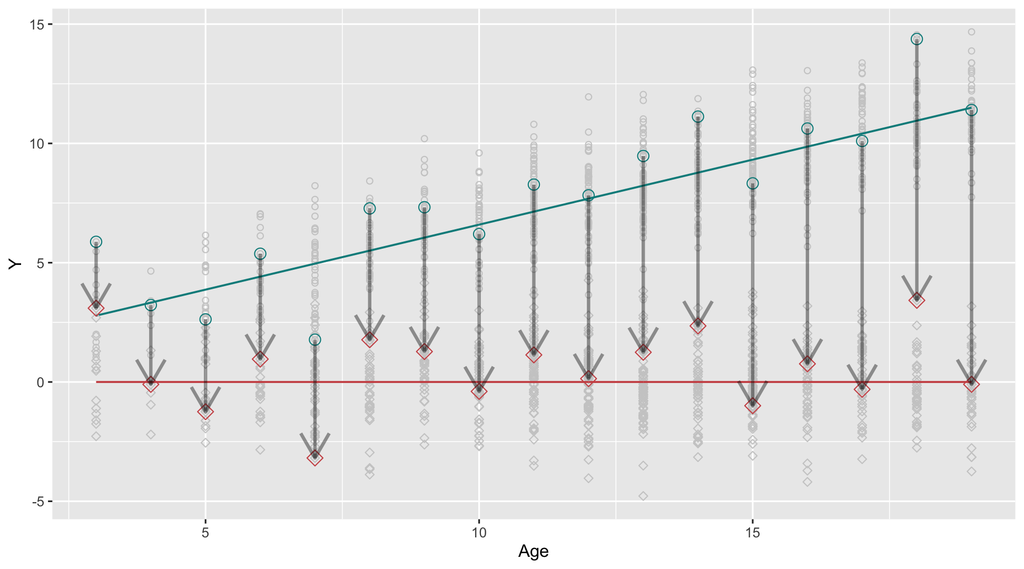

```r
mod_vec
```

## Hence, the Answers

- What is the unit of `\(\alpha\)`?

This is the unit of the variable plotted on the `\(y\)`-axis, i.e. that of `LungCap`. E.g., if lung capacity was measured in decilitres, then the unit of the `\(y\)`-intercept would be decilitres, or `\(dL\)`.

- What is the unit of `\(\beta\)`?

The slope is `\(\frac{\Delta y} {\Delta x}\)`, i.e. `\(y \cdot x^{-1}\)`, or in the units of the variables used in the example, `\(dL \cdot yr^{-1}\)`. This means that for every year that a person in this population ages, the lung capacity would increase by 0.55 `\(dL\)`.

- What would be the slope of a linear model fitted to the residuals?

Zero, 0

- What would be the intercept of a linear model fitted to the residuals?

Zero, 0

- State the null hypotheses for the intercept and slope for this linear model, and provide statistical support for accepting/not accepting the linear model fitted to the residuals.

- What is the significance of the overall model fit?

`F-statistic:  1480 on 1 and 723 DF,  p-value: < 2.2e-16`, i.e. a linear model describes a significant proportion of the response that lung volume shows as a function of age. Looking at the Adjusted `\(r^{2}\)`,the linear model explains 67.14% of this variation. The rest of the variance left unexplained is due to unaccounted for sources of variation, such as intrinsic between human differences.

- Why (to all of the above)?

The residuals show 0 slope and 0 intercept because in effect this is what the linear model does, viz. it 'subtracts' or removes the linear variation that lung capacity shows with age from the raw data, and what is left over are data without slope (a flat line) that intersects with the `\(y\)`-axis at 0. What is left over is variation that exists in the data that is not due to age.

- Create a plot of the fitted line added to the scatterplot of residuals.

See above.